# ANOVA

April 16, 2018

## ANOVA

Consider the facebook dataset. Does the avergae number of likes depend on what type of post you make?

Figure out the average number of likes for each of the types. What is the average number of likes for all posts? Distribution of the number of likes for each type? For all types?

## Example

```r
fb %>% group_by(Type) %>% summarize(mean=mean(`Page total likes`))
```

```
## # A tibble: 4 x 2
##   Type      mean
##   <chr>    <dbl>
## 1 Link   116363.
## 2 Photo  122354.
## 3 Status 132647.
## 4 Video  135015.
```

## Thinking regression

Do a simple linear regression predicting likes from type of post. Get a summary and an anova table.

## Results

```r
modlinear <- fb %>% lm(`Page total likes`~Type, data=.)
summary(modlinear)
```

```
##
## Call:
## lm(formula = `Page total likes` ~ Type, data = .)
##
## Residuals:
##    Min     1Q Median     3Q    Max
## -40984 -10734   4070  13359  22532
##
## Coefficients:
##             Estimate Std. Error t value Pr(>|t|)
## (Intercept)   116363       3396  34.270  < 2e-16 ***
## TypePhoto       5991       3482   1.721   0.0860 .
## TypeStatus     16284       4143   3.930 9.69e-05 ***
## TypeVideo      18652       6911   2.699   0.0072 **
## ---
## Signif. codes:  0 '***' 0.001 '**' 0.01 '*' 0.05 '.' 0.1 ' ' 1
##
## Residual standard error: 15930 on 496 degrees of freedom
## Multiple R-squared:  0.04788,    Adjusted R-squared:  0.04212
## F-statistic: 8.314 on 3 and 496 DF,  p-value: 2.102e-05
```

## ANOVA table

```r
anova(modlinear)
```

```
## Analysis of Variance Table
##
## Response: Page total likes
##            Df     Sum Sq    Mean Sq F value    Pr(>F)
## Type        3 6.3263e+09 2108771838  8.3137 2.102e-05 ***
## Residuals 496 1.2581e+11  253651421
## ---
## Signif. codes:  0 '***' 0.001 '**' 0.01 '*' 0.05 '.' 0.1 ' ' 1
```

## Model

```r
mod1 <- fb %>% aov(`Page total likes`~Type, data=.)
summary(mod1)
```

```
##              Df    Sum Sq   Mean Sq F value  Pr(>F)
## Type          3 6.326e+09 2.109e+09   8.314 2.1e-05 ***
## Residuals   496 1.258e+11 2.537e+08
## ---
## Signif. codes:  0 '***' 0.001 '**' 0.01 '*' 0.05 '.' 0.1 ' ' 1
```

## Meaning of ANOVA

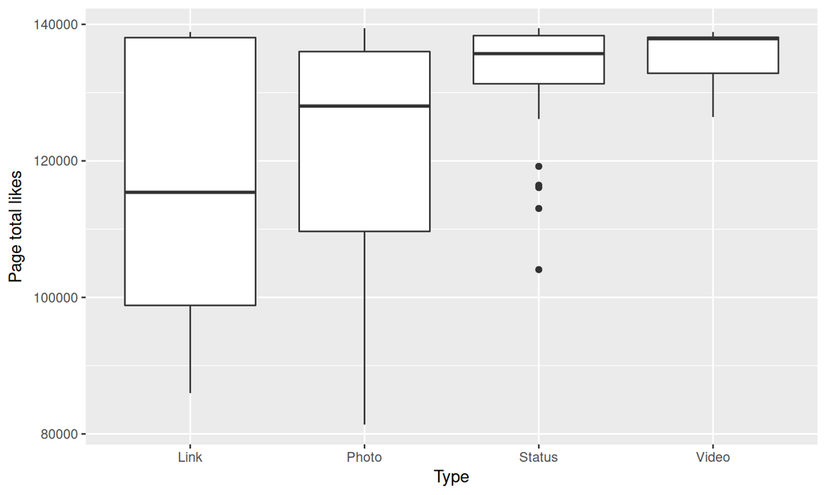

```r
fb %>% ggplot(aes(x=Type, y = `Page total likes`))+geom_boxplot()
```

## Better yet

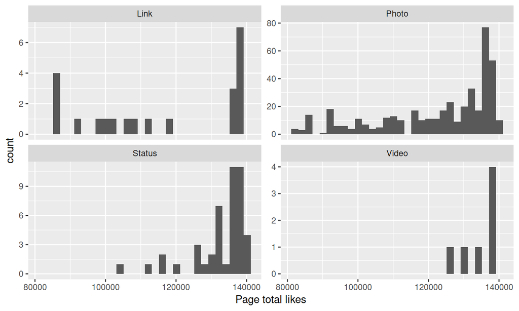

```r
fb %>% ggplot(aes(x=`Page total likes`))+geom_histogram()+facet_wrap(~Type, scales="free_y")
```

## Setup

Observation = Group mean + Error

Group mean = Grant mean + Group effect

Response = Grand mean + Group effect + Error term \[Y = \mu + a_k + \epsilon\]

but

\[\mu_k = \mu + \alpha_k\]

## Plotted

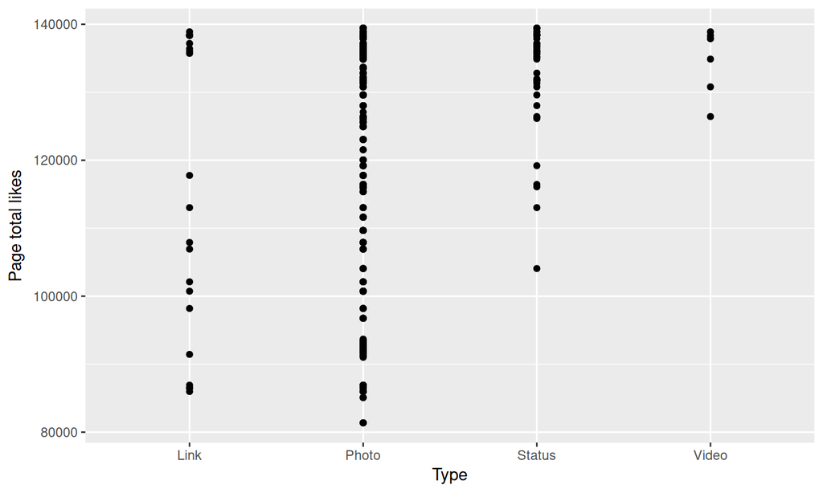

```r
fb %>% ggplot(aes(x = Type, y = `Page total likes`))+geom_point()
```

## Back to the table: df

```r
mod1 <- fb %>% aov(`Page total likes`~Type, data=.)
summary(mod1)
```

```
##              Df    Sum Sq   Mean Sq F value  Pr(>F)
## Type          3 6.326e+09 2.109e+09   8.314 2.1e-05 ***
## Residuals   496 1.258e+11 2.537e+08
## ---
## Signif. codes:  0 '***' 0.001 '**' 0.01 '*' 0.05 '.' 0.1 ' ' 1
```

## Hypothesis Test

\(H_0: \alpha_1 = \alpha_2 = ... = \alpha_K = 0\)

\(H_A:\) at least one \(\alpha_k \neq 0\)

## What do these mean?

\(\hat{\mu} = \bar{y}\)

When is it true that \(\hat{y} = \bar{y}\)?

\(\hat{\alpha}_k = \bar{y}_k - \hat{\mu} = \bar{y}_k - \bar{y}\)

\(\hat{\epsilon} = y - \hat{y} = y - \hat{\mu} - \hat{\alpha}_k = y - \bar{y}_k\)

## So…

Estimated values:

\(\hat{\mu} = \bar{y}\)

\(\hat{\alpha}_k = \bar{y}_k - \bar{y}\)

\(\hat{\epsilon} = y - \bar{y}_k\)

## Assumptions

- Residuals have mean 0
- These normal populations have a common variance
  - Can use Levene’s test to check this
- Residuals are normally distributed (at each level)
  - (Kolmogorov–Smirnov test)
  - (Shapiro–Wilk test)
- Residuals are independent

## Resduals have mean 0

```r
mean(mod1$residuals)
```

```
## [1] 2.629235e-12
```

```r
fb$residuals <- mod1$residuals
fb %>% group_by(Type) %>% summarise(mean=mean(residuals))
```

```
## # A tibble: 4 x 2
##   Type        mean
##   <chr>      <dbl>
## 1 Link    9.03e-11
## 2 Photo  -1.61e-12
## 3 Status  7.57e-12
## 4 Video  -4.39e-11
```

## Common variance

```r
fb %>% group_by(Type) %>% summarise(var = var(residuals))
```

```
## # A tibble: 4 x 2
##   Type          var
##   <chr>       <dbl>
## 1 Link   460521615.
## 2 Photo  266490237.
## 3 Status  62443900.
## 4 Video   22378119.
```

```r
460521615/22378119
```

```
## [1] 20.5791
```

(2 would be better…)

## Normal residuals

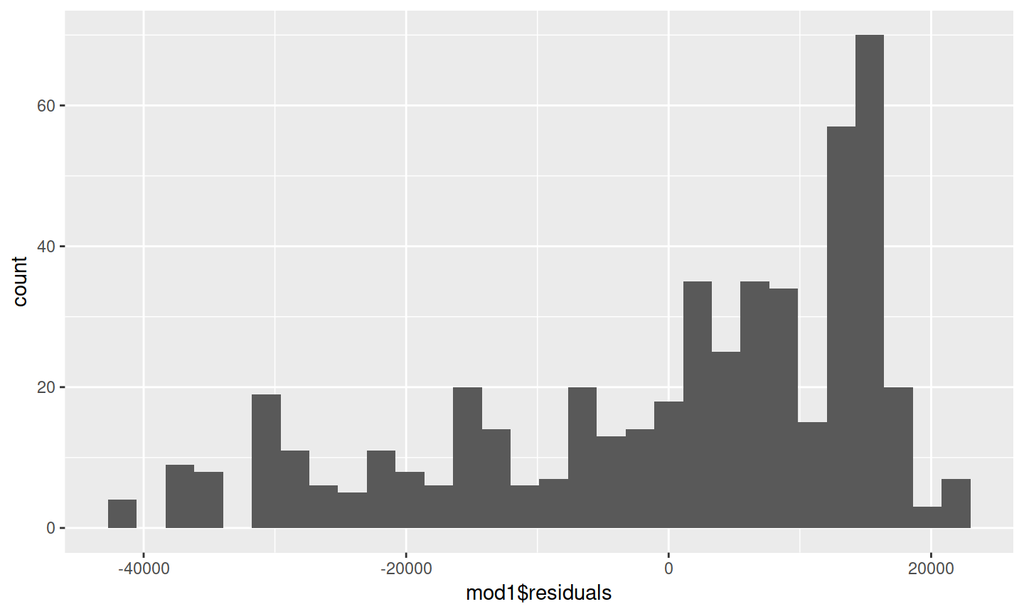

```r
qplot(mod1$residuals)
```

## By type

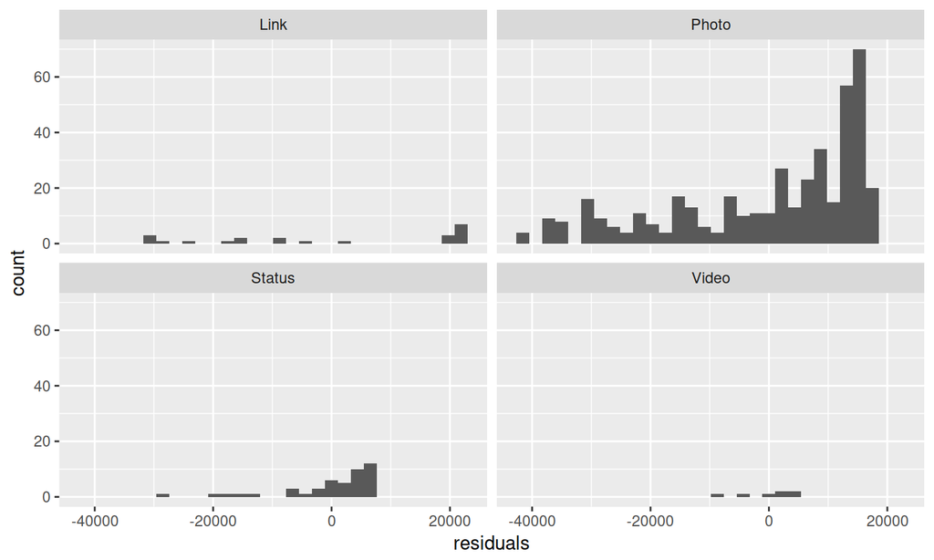

```r
fb %>% ggplot(aes(x = residuals))+geom_histogram() + facet_wrap(~Type)
```

## Residuals vs fitted - same spread?

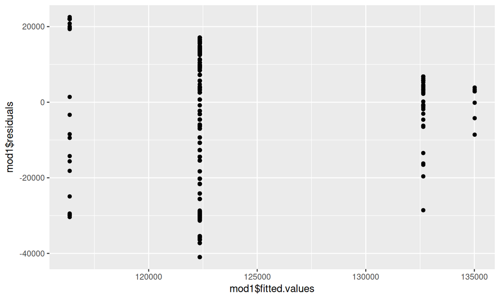

```r
qplot(mod1$fitted.values,mod1$residuals)
```

## How could we fix these broken assumptions?